# Binomial Distribution Response to Urban Heat

Joey Hulbert

Last Update: 2024-08-26

| [Welcome](https://jmhulbert.github.io/redhot) | [Data](https://jmhulbert.github.io/redhot/data) | [Analyses](https://jmhulbert.github.io/redhot/analyses) | [Discussion](https://jmhulbert.github.io/redhot/discussion) | [Maps](https://jmhulbert.github.io/redhot/maps) |
| --- | --- | --- | --- | --- |

|  |  |  | Analyses |  |  |  |
| --- | --- | --- | --- | --- | --- | --- |
| [Urban Heat](https://jmhulbert.github.io/redhot/analyses/heat/) | [All Areas](https://jmhulbert.github.io/redhot/analyses/heat/all-areas) | [Portland](https://jmhulbert.github.io/redhot/analyses/heat/portland) | [Tacoma](https://jmhulbert.github.io/redhot/analyses/heat/tacoma) | [King County](https://jmhulbert.github.io/redhot/analyses/heat/king-county) | [iNaturalist](https://jmhulbert.github.io/redhot/analyses/inaturalist/) | City Inventories |

```r
library(tidyverse)
library(corrplot)
library(knitr)
library(kableExtra)
library(gghalves)
library(patchwork)
library(scales)
library(glmmTMB)
library(bbmle)
library(DHARMa)
```

# Purpose

The purpose of this page is to summarize an investigation of **tree health categories** as a *categorical* response to urban heat (temperatures).

Response variable: category: *healthy, unhealthy*

# Data Wrangling

```r
data <- read.csv('https://raw.githubusercontent.com/jmhulbert/redhot/main/data/urban-data-modified.csv')
```

## Remove dead trees

```r
# Remove Dead Trees
data.w.dead <- data
data <- data %>% filter(field.tree.canopy.symptoms!="Tree is dead") %>% filter(field.dieback.percent<100) %>% droplevels()
```

```r
data$binary.tree.canopy.symptoms <- as.factor(data$binary.tree.canopy.symptoms)
levels(data$binary.tree.canopy.symptoms)
```

```
## [1] "Healthy"   "Unhealthy"
```

## Remove observations from Hoyt

```r
data <- data %>% filter(!str_detect(place_guess, "Hoyt") & !str_detect(place_guess, "hoyt"))
```

# Data Visualization

## Binary Tree Condition Categories

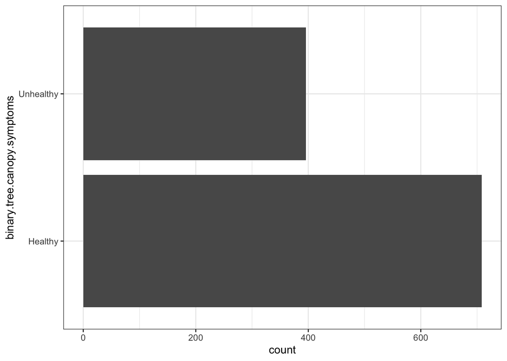

```r
ggplot(data,aes(binary.tree.canopy.symptoms))+geom_histogram(stat="count")+theme_bw()+coord_flip()
```

```r
p1 <-ggplot(data,aes(binary.tree.canopy.symptoms,dist.from.mean.af, fill=binary.tree.canopy.symptoms ))+geom_boxplot(alpha=0.5)+theme_bw()+coord_flip() + scale_fill_manual(name="Tree Condition",values=c("#7fcdbb","#fe9929"))+guides(fill=FALSE) +labs(x="Tree Condition",y=NULL)
p2 <-ggplot(data,aes(dist.from.mean.af,fill=binary.tree.canopy.symptoms))+geom_density(alpha=0.5) + scale_fill_manual(name="Tree Condition",values=c("#7fcdbb","#fe9929")) +theme_bw() +labs(x="Distance from Mean Afternoon Temperature") +guides(fill=FALSE)
```

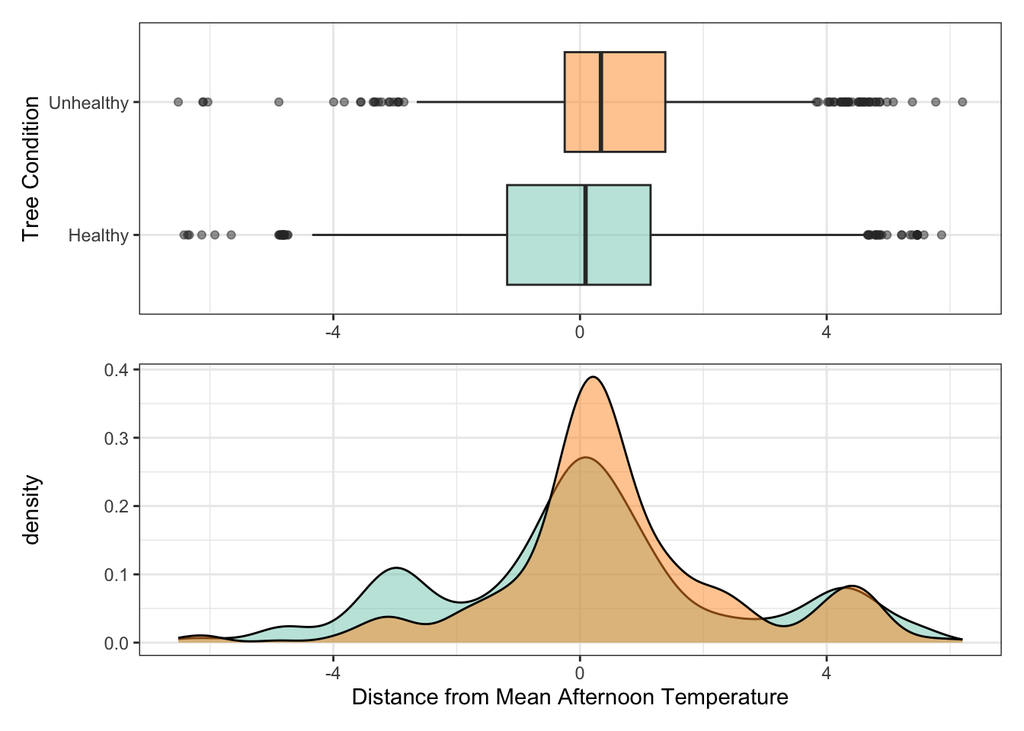

```r
p1 / p2
```

## Reclassified Tree Condition Categories

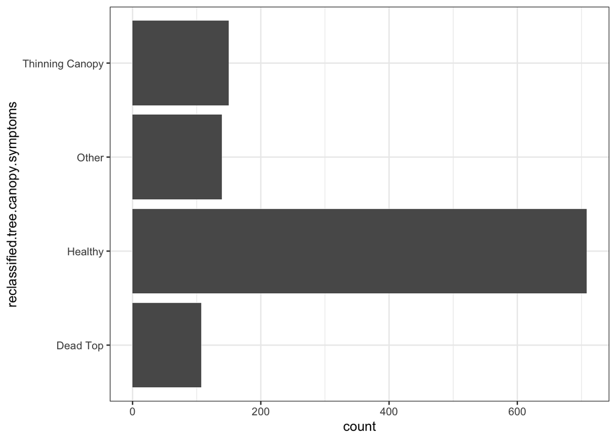

```r
ggplot(data,aes(reclassified.tree.canopy.symptoms))+geom_histogram(stat="count")+theme_bw()+coord_flip()
```

```r
data$top.dieback <- as.factor(data$top.dieback)
data$thinning <- as.factor(data$thinning)
```

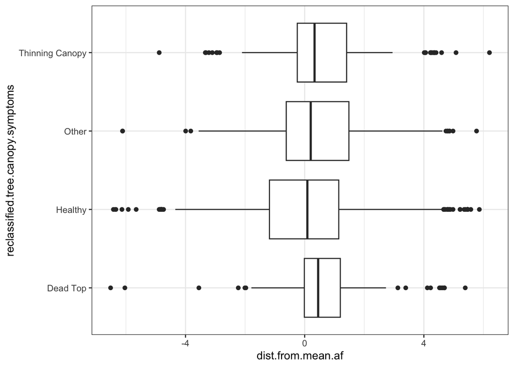

```r
ggplot(data,aes(reclassified.tree.canopy.symptoms,dist.from.mean.af ))+geom_boxplot()+theme_bw()+coord_flip()
```

## Temp and Site Type

```r
king <- data %>% filter(Area=="King County")
```

```r
king <- king %>% filter(field.optional...site.type=="Urban"|field.optional...site.type=="Suburban"|field.optional...site.type=="Rural")
```

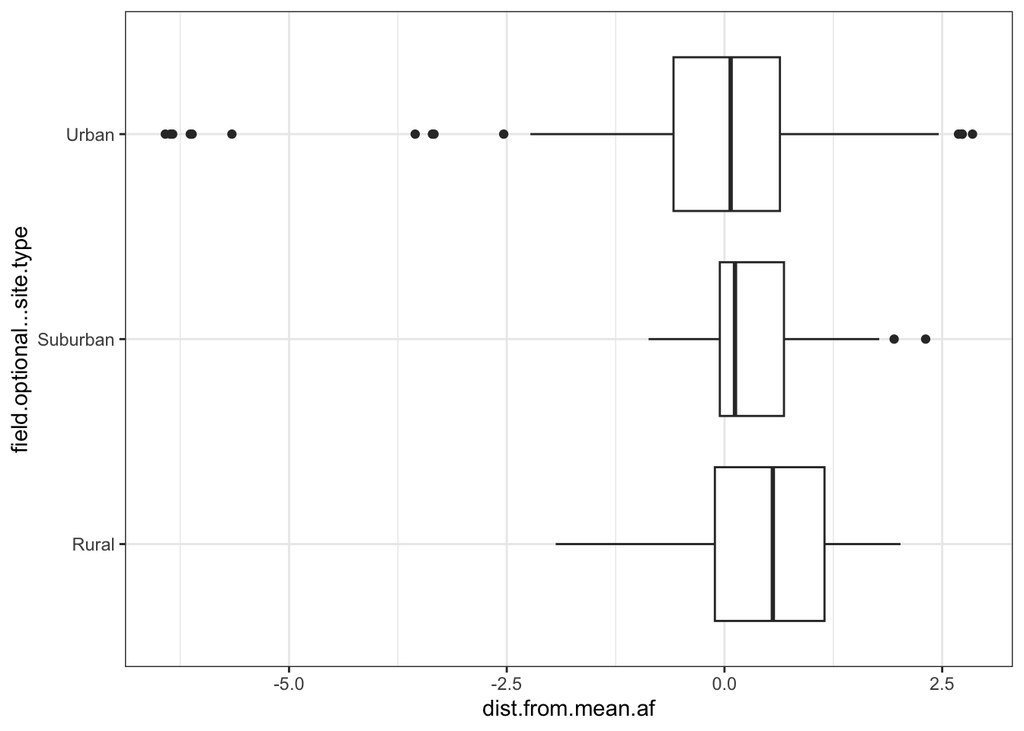

```r
ggplot(king,aes(field.optional...site.type,dist.from.mean.af ))+geom_boxplot()+theme_bw()+coord_flip()
```

# Analyses

## Time Series Model Fit

```r
binomial.daily <- glmmTMB(binary.tree.canopy.symptoms ~ dist.from.mean.daily + (1|Area),family=binomial,data=data)
binomial.am <- glmmTMB(binary.tree.canopy.symptoms ~ dist.from.mean.am + (1|Area),data=data,family=binomial)
binomial.af <- glmmTMB(binary.tree.canopy.symptoms ~ dist.from.mean.af + (1|Area),data=data,family=binomial)
binomial.pm <- glmmTMB(binary.tree.canopy.symptoms ~ dist.from.mean.pm + (1|Area),data=data,family=binomial)
```

### Compare Time Series Models

```r
AICtab(binomial.daily,binomial.am,binomial.af,binomial.pm)
```

```
##                dAIC df
## binomial.af     0.0 3
## binomial.am    16.4 3
## binomial.daily 16.6 3
## binomial.pm    18.1 3
```

Afternoon heat was the best fit

## Response 1.0: healthy / unhealthy

```r
#binomial.af <- glmmTMB(binary.tree.canopy.symptoms ~ dist.from.mean.af + (1|Area),data=data,family=binomial)
```

### Summary

```r
summary(binomial.af)
```

```
##  Family: binomial  ( logit )
## Formula:          binary.tree.canopy.symptoms ~ dist.from.mean.af + (1 | Area)
## Data: data
##
##      AIC      BIC   logLik deviance df.resid
##   1402.2   1417.2   -698.1   1396.2     1101
##
## Random effects:
##
## Conditional model:
##  Groups Name        Variance Std.Dev.
##  Area   (Intercept) 0.2044   0.4522
## Number of obs: 1104, groups:  Area, 3
##
## Conditional model:
##                   Estimate Std. Error z value Pr(>|z|)
## (Intercept)       -0.69512    0.27004  -2.574     0.01 *
## dist.from.mean.af  0.13977    0.03219   4.343 1.41e-05 ***
## ---
## Signif. codes:  0 '***' 0.001 '**' 0.01 '*' 0.05 '.' 0.1 ' ' 1
```

Tree health is associated with urban heat. The probability of success (tree categorized as unhealthy) increases with urban heat

Unhealthy trees are considered success (1) because it is the second level. The probability of failure (0) is the first level (Healthy).

```r
levels(data$binary.tree.canopy.symptoms)
```

```
## [1] "Healthy"   "Unhealthy"
```

The probability of a tree being classified as unhealthy increases with urban temperature.

```r
#predict(binomial.af,data[data$DN_AF1=0,])
#predict(binomial.af,DN_AF1=0)
```

### Visualize effects of predictors

First, generate predictions from model

```r
# Create a data frame for predictions
new.data <- expand.grid(
  dist.from.mean.af = seq(min(data$dist.from.mean.af), max(data$dist.from.mean.af), length.out = 100),  # keeping predictor2 constant at its mean
  Area = 0  # assuming random effect is zero for prediction
)
```

```r
new.data$predicted_response <- predict(binomial.af, newdata = new.data, type = "response")
```

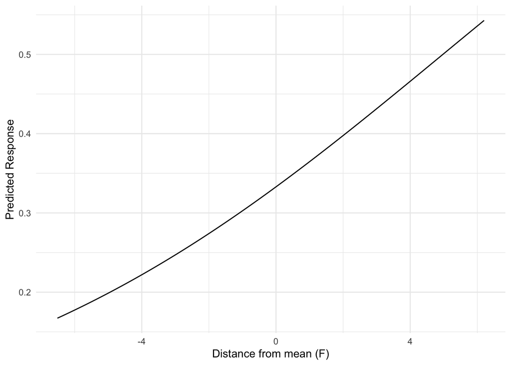

```r
p1 <- ggplot(new.data, aes(x = dist.from.mean.af, y = predicted_response)) +
  geom_line() +
  labs(x = "Distance from mean (F)", y = "Predicted Response") +
  theme_minimal()
p1
```

```r
# Create a data frame for predictions
new.data.2.inf <- expand.grid(
  dist.from.mean.af = seq(min(data$dist.from.mean.af), max(100), length.out = 1000), Area = 0)  # keeping predictor2 constant at its mean
```

```r
new.data.2.inf$predicted_response <- predict(binomial.af, newdata = new.data.2.inf, type = "response")
```

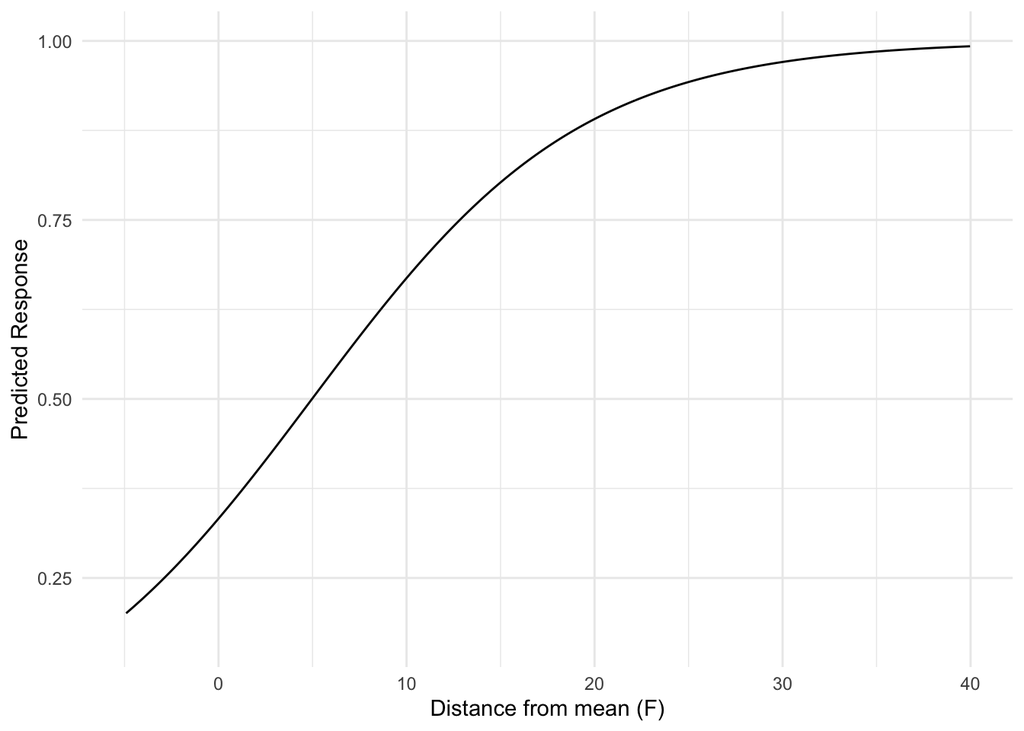

```r
p2 <- ggplot(new.data.2.inf, aes(x = dist.from.mean.af, y = predicted_response)) + geom_line() + labs(x = "Distance from mean (F)", y = "Predicted Response") + scale_x_continuous(limits = c(-5, 40)) +theme_minimal()

p2
```

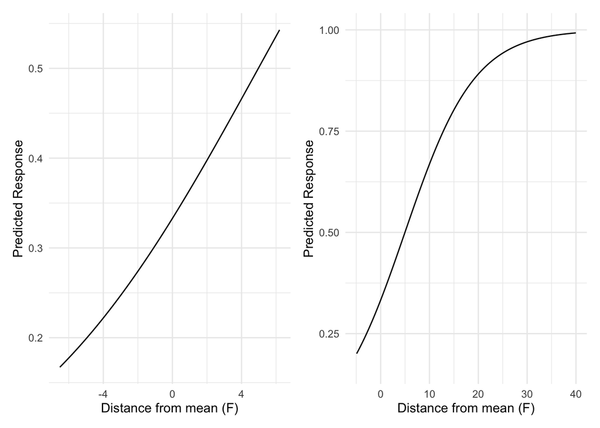

```r
p1 + p2
```

Probability when standardized temperature value is -2

```r
new_data <- data.frame(dist.from.mean.af = -2,Area=0)
predicted_response <- predict(binomial.af, newdata = new_data, type = "response")
print(predicted_response)
```

```
## [1] 0.2739535
```

Probability when standardized temperature value is 0

```r
new_data <- data.frame(dist.from.mean.af = 0,Area=0)
predicted_response <- predict(binomial.af, newdata = new_data, type = "response")
print(predicted_response)
```

```
## [1] 0.3328951
```

Probability when standardized temperature value is 2

```r
new_data <- data.frame(dist.from.mean.af = 2,Area=0)
predicted_response <- predict(binomial.af, newdata = new_data, type = "response")
print(predicted_response)
```

```
## [1] 0.3975739
```

The probability of tree being classified as unhealthy increases with distance from mean af

## Response 2.0: healthy / top-dieback

```r
data.top <- data %>% filter(reclassified.tree.canopy.symptoms=="Healthy"|reclassified.tree.canopy.symptoms=="Dead Top") %>% droplevels()
```

```r
top.dieback.binomial.af <- glmmTMB(top.dieback ~ dist.from.mean.af + (1|Area),data=data.top,family=binomial)
```

### Summary

```r
summary(top.dieback.binomial.af)
```

```
##  Family: binomial  ( logit )
## Formula:          top.dieback ~ dist.from.mean.af + (1 | Area)
## Data: data.top
##
##      AIC      BIC   logLik deviance df.resid
##    602.8    616.9   -298.4    596.8      812
##
## Random effects:
##
## Conditional model:
##  Groups Name        Variance Std.Dev.
##  Area   (Intercept) 0.6071   0.7792
## Number of obs: 815, groups:  Area, 3
##
## Conditional model:
##                   Estimate Std. Error z value Pr(>|z|)
## (Intercept)        -2.2149     0.4729  -4.683 2.82e-06 ***
## dist.from.mean.af   0.2386     0.0688   3.468 0.000525 ***
## ---
## Signif. codes:  0 '***' 0.001 '**' 0.01 '*' 0.05 '.' 0.1 ' ' 1
```

Tree health is associated with urban heat. The probability of success (tree categorized as unhealthy) increases with urban heat

Unhealthy trees are considered success (1) because it is the second level. The probability of failure (0) is the first level (Healthy).

```r
levels(data$top.dieback)
```

```
## [1] "No"  "Yes"
```

```r
p3 <-ggplot(data,aes(top.dieback,dist.from.mean.af, fill=top.dieback ))+geom_boxplot(alpha=0.5)+theme_bw()+coord_flip() + scale_fill_manual(name="Top Dieback",values=c("#7fcdbb","#fe9929"))+guides(fill=FALSE) +labs(x="Top Dieback",y=NULL)
```

```r
p4 <-ggplot(data,aes(dist.from.mean.af,fill=top.dieback))+geom_density(alpha=0.5) + scale_fill_manual(name="Top Dieback",values=c("#7fcdbb","#fe9929")) +theme_bw() +labs(x="Distance from Mean Afternoon Temperature") +guides(fill=FALSE)
```

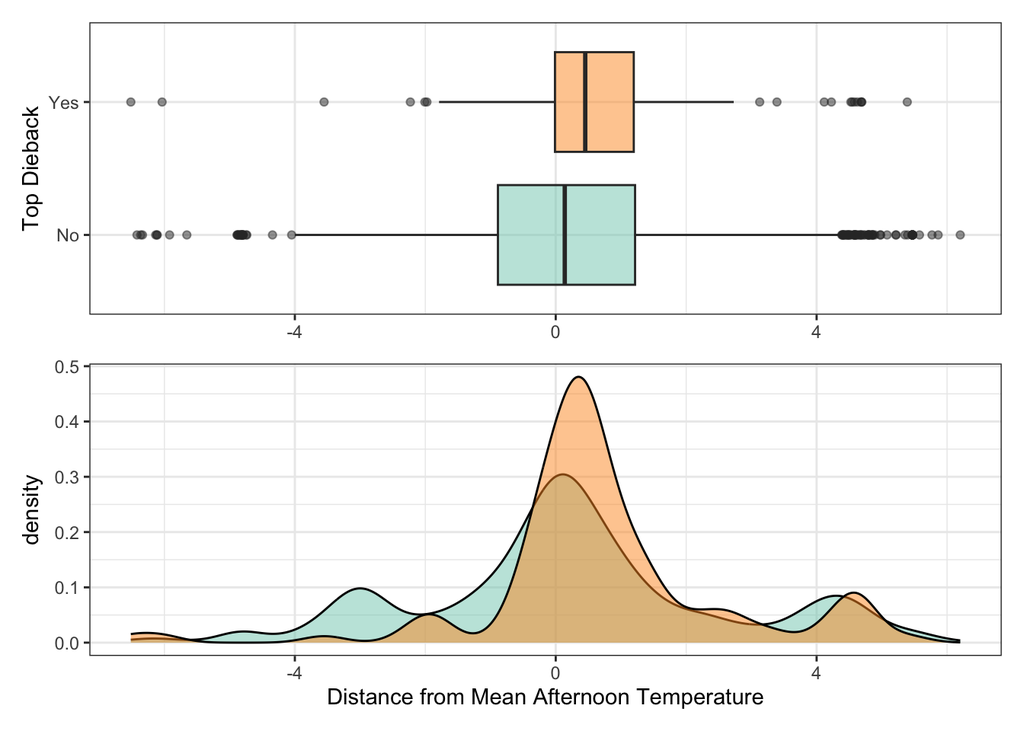

```r
p3 / p4
```

The probability of a tree having top dieback increases with urban temperature.

### Visualize effects of predictors

First, generate predictions from model

```r
# Create a data frame for predictions
new.data.2 <- expand.grid(
  dist.from.mean.af = seq(min(data$dist.from.mean.af), max(data$dist.from.mean.af), length.out = 100),  # keeping predictor2 constant at its mean
  Area = 0  # assuming random effect is zero for prediction
)
```

```r
new.data.2$predicted_response <- predict(top.dieback.binomial.af, newdata = new.data.2, type = "response")
```

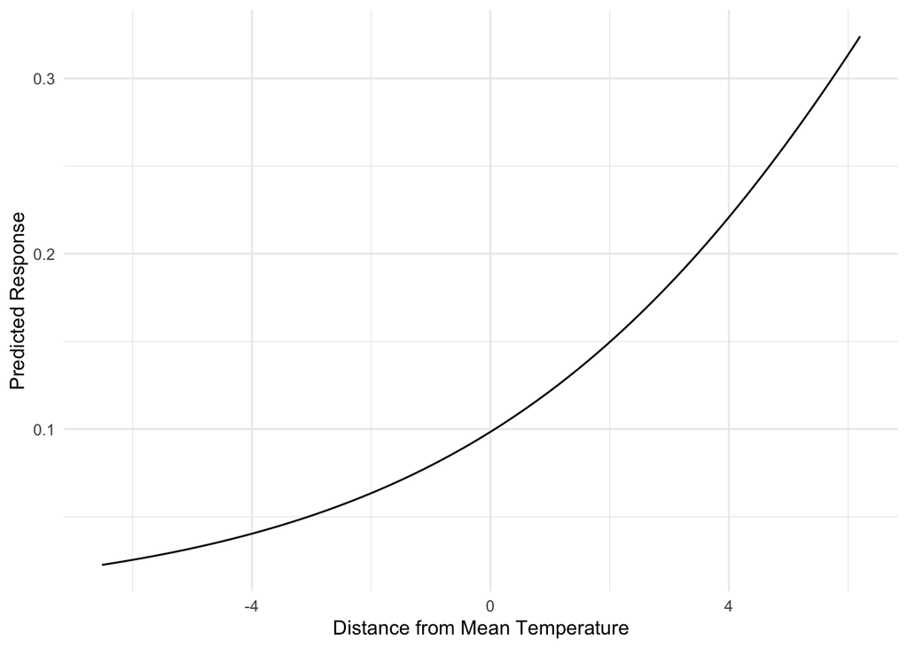

```r
ggplot(new.data.2, aes(x = dist.from.mean.af, y = predicted_response)) +
  geom_line() +
  labs(x = "Distance from Mean Temperature", y = "Predicted Response") +
  theme_minimal()
```

Probability when standardized temperature value is 0

```r
new_data <- data.frame(dist.from.mean.af = 0,Area=0)
predicted_response <- predict(top.dieback.binomial.af, newdata = new_data, type = "response")
print(predicted_response)
```

```
## [1] 0.09841986
```

Probability when standardized temperature value is 2

```r
new_data <- data.frame(dist.from.mean.af = 2,Area=0)
predicted_response <- predict(top.dieback.binomial.af, newdata = new_data, type = "response")
print(predicted_response)
```

```
## [1] 0.1495957
```

## Response 3.0: healthy / thinning

```r
data.thin <- data %>% filter(reclassified.tree.canopy.symptoms=="Healthy"|reclassified.tree.canopy.symptoms=="Thinning Canopy") %>% droplevels()
```

```r
thinning.binomial.af <- glmmTMB(thinning ~ dist.from.mean.af + (1|Area),data=data.thin,family=binomial)
```

### Summary

```r
summary(thinning.binomial.af)
```

```
##  Family: binomial  ( logit )
## Formula:          thinning ~ dist.from.mean.af + (1 | Area)
## Data: data.thin
##
##      AIC      BIC   logLik deviance df.resid
##    786.7    800.9   -390.3    780.7      855
##
## Random effects:
##
## Conditional model:
##  Groups Name        Variance Std.Dev.
##  Area   (Intercept) 0.1578   0.3973
## Number of obs: 858, groups:  Area, 3
##
## Conditional model:
##                   Estimate Std. Error z value Pr(>|z|)
## (Intercept)       -1.63907    0.24977  -6.562  5.3e-11 ***
## dist.from.mean.af  0.12305    0.04641   2.651  0.00802 **
## ---
## Signif. codes:  0 '***' 0.001 '**' 0.01 '*' 0.05 '.' 0.1 ' ' 1
```

Tree health is associated with urban heat. The probability of success (tree categorized as unhealthy) increases with urban heat

Unhealthy trees are considered success (1) because it is the second level. The probability of failure (0) is the first level (Healthy).

```r
levels(data$thinning)
```

```
## [1] "No"  "Yes"
```

The probability of a tree being classified as unhealthy increases with urban temperature.

### Visualize effects of predictors

First, generate predictions from model

```r
# Create a data frame for predictions
new.data.3 <- expand.grid(
  dist.from.mean.af = seq(min(data$dist.from.mean.af), max(data$dist.from.mean.af), length.out = 100),  # keeping predictor2 constant at its mean
  Area = 0  # assuming random effect is zero for prediction
)
```

```r
new.data.3$predicted_response <- predict(thinning.binomial.af, newdata = new.data.3, type = "response")
```

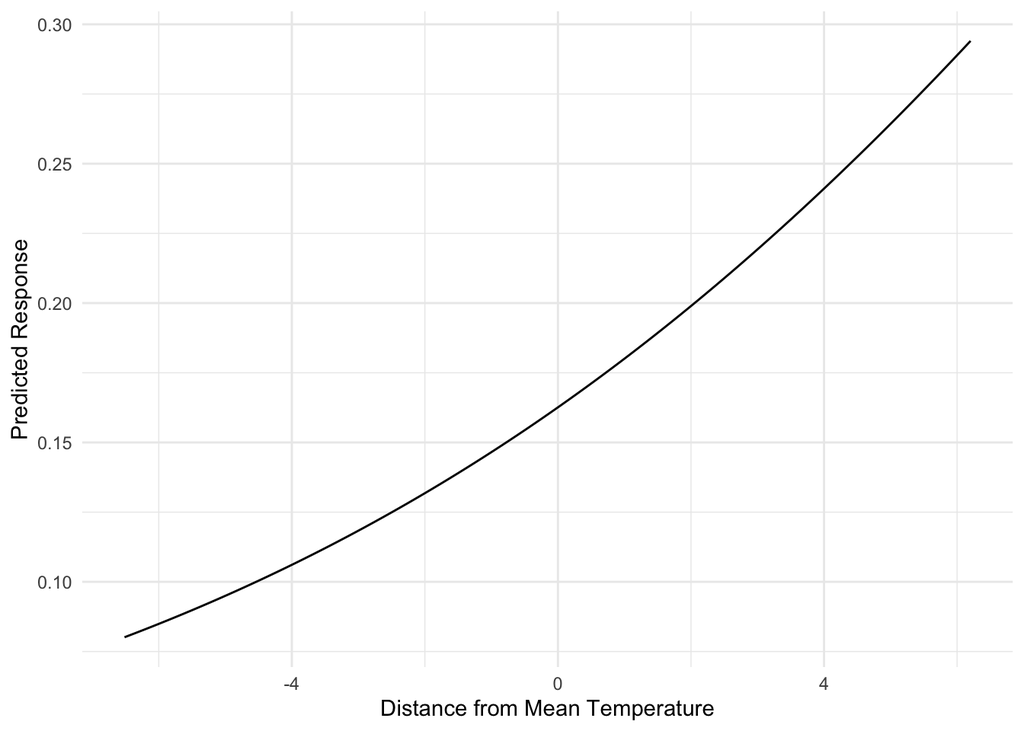

```r
ggplot(new.data.3, aes(x = dist.from.mean.af, y = predicted_response)) +
  geom_line() +
  labs(x = "Distance from Mean Temperature", y = "Predicted Response") +
  theme_minimal()
```

### Compare models

#### Odds Ratios

Unhealthy Trees

```r
# Unhealthy Overall
coef(binomial.af)
```

```
## $Area
##             (Intercept) dist.from.mean.af
## King County   -0.272711         0.1397678
## Portland      -1.296521         0.1397678
## Tacoma        -0.510957         0.1397678
```

```r
exp(0.1397678)
```

```
## [1] 1.150007
```

Top Dieback

```r
# Top Dieback
coef(top.dieback.binomial.af)
```

```
## $Area
##             (Intercept) dist.from.mean.af
## King County   -1.363863         0.2385653
## Portland      -3.177853         0.2385653
## Tacoma        -2.062167         0.2385653
```

```r
exp(0.2385653)
```

```
## [1] 1.269427
```

Thinning

```r
# Thinning
coef(thinning.binomial.af)
```

```
## $Area
##             (Intercept) dist.from.mean.af
## King County   -1.355800          0.123049
## Portland      -2.151415          0.123049
## Tacoma        -1.391666          0.123049
```

```r
exp(0.09135893)
```

```
## [1] 1.095662
```

> “An odds ratio greater than 1 implies that the predictor increases the odds of the outcome.”

Heat had the largest effect on predicting if trees had top dieback

## Models with Co-Factors

Note the models below were tested on filtered data. Data categorized as ‘No Selection’, ‘Other’ or blank were filtered out.

### Co-Factor Model 1: adding size

#### Visualize co-factor

```r
data.size.filter <- data %>% filter(tree.size.simplified!="" & tree.size.simplified!="No Selection")
levels(as.factor(data.size.filter$tree.size.simplified))
```

```
## [1] "Large"  "Medium" "Small"
```

223 were removed from the data. 881 observations were used in below the co-factor model adding size below.

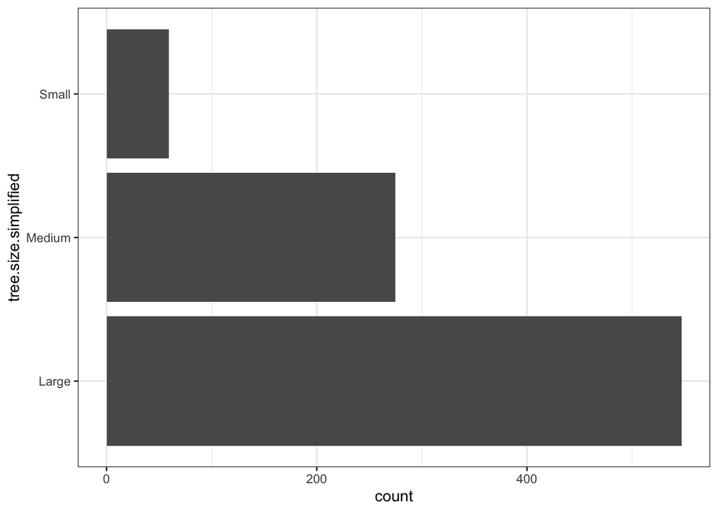

```r
ggplot(data.size.filter,aes(tree.size.simplified))+geom_histogram(stat="count")+coord_flip()+theme_bw()
```

##### All Trees

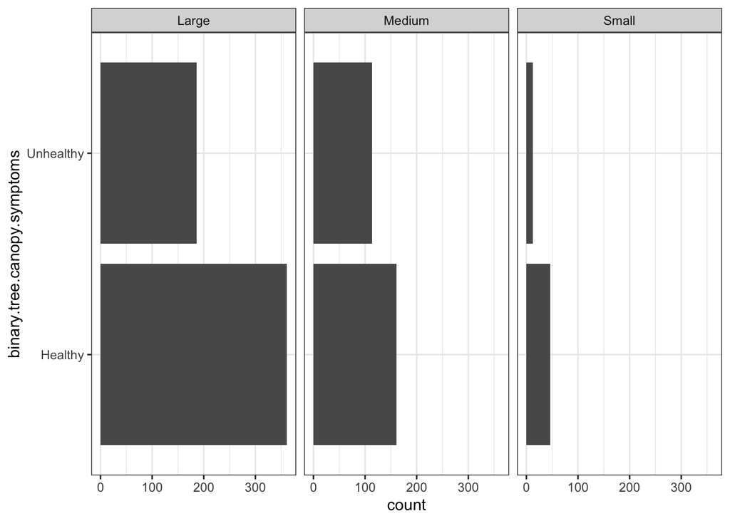

```r
ggplot(data.size.filter,aes(binary.tree.canopy.symptoms)) +facet_wrap(~tree.size.simplified) +geom_histogram(stat="count")+theme_bw()+coord_flip()
```

##### Trees with Dead Tops

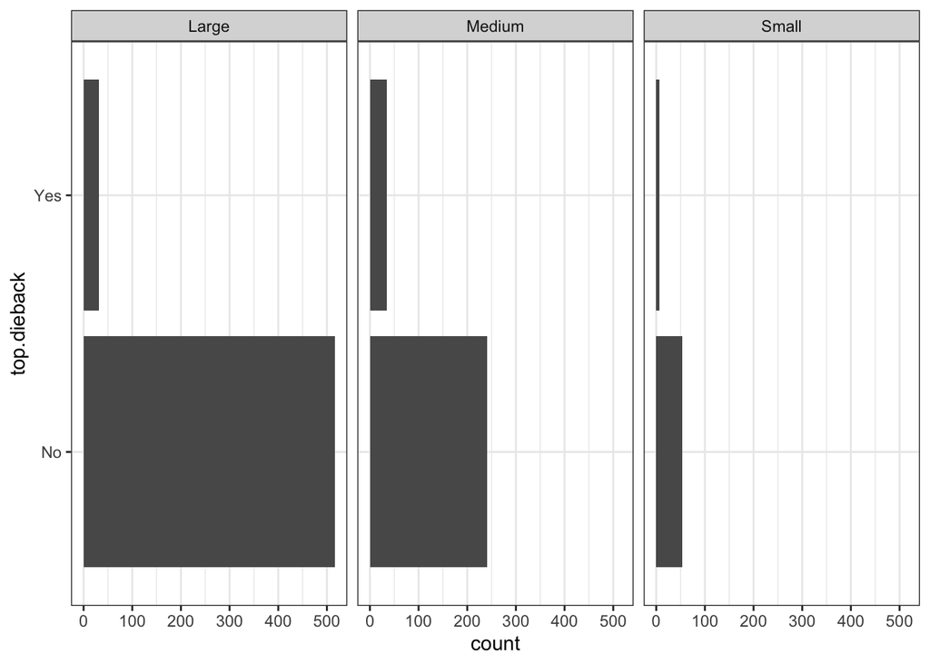

```r
ggplot(data.size.filter,aes(top.dieback)) +facet_wrap(~tree.size.simplified) +geom_histogram(stat="count")+theme_bw()+coord_flip()
```

##### Thinning Trees

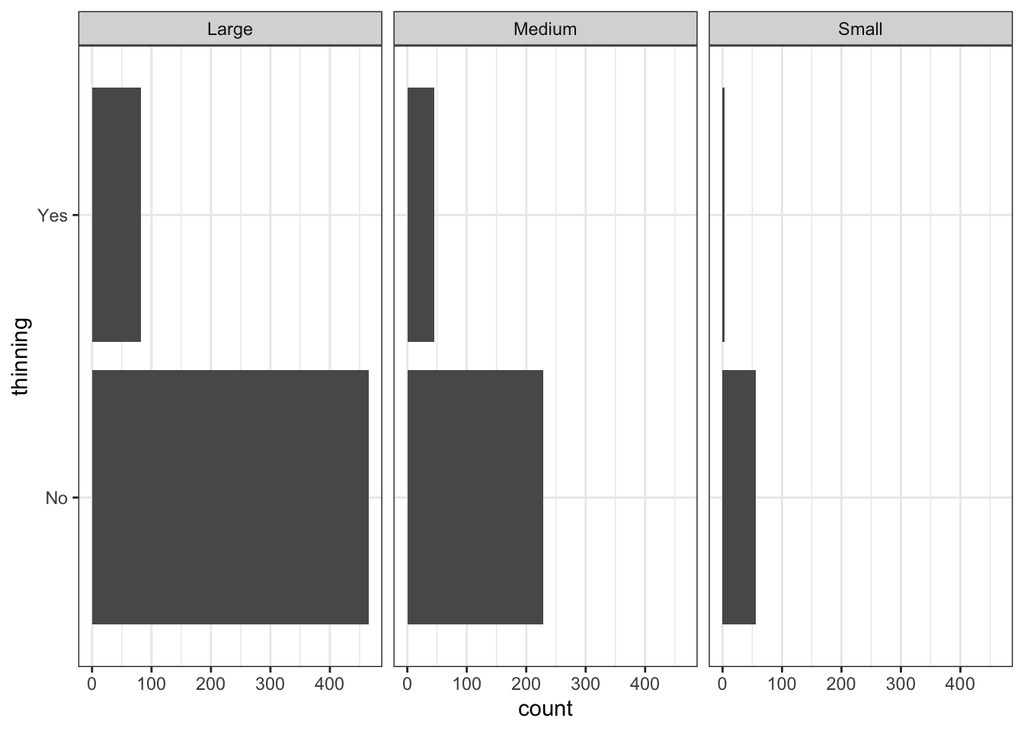

```r
ggplot(data.size.filter,aes(thinning)) +facet_wrap(~tree.size.simplified) +geom_histogram(stat="count")+theme_bw()+coord_flip()
```

#### Response 1.1 healthy / unhealthy

```r
binomial.af.size <- glmmTMB(binary.tree.canopy.symptoms ~ dist.from.mean.af +  tree.size.simplified +(1|Area),data=data.size.filter,family=binomial)
```

##### Overall Effect

```r
# Fit the reduced model (without site location description)
reduced_model.binomial.size <- glmmTMB(binary.tree.canopy.symptoms ~ dist.from.mean.af + (1 | Area),
                       data = data.size.filter,
                       family = binomial)

# Perform a likelihood ratio test
anova(reduced_model.binomial.size, binomial.af.size, test = "Chisq")
```

```
## Data: data.size.filter
## Models:
## reduced_model.binomial.size: binary.tree.canopy.symptoms ~ dist.from.mean.af + (1 | Area), zi=~0, disp=~1
## binomial.af.size: binary.tree.canopy.symptoms ~ dist.from.mean.af + tree.size.simplified + , zi=~0, disp=~1
## binomial.af.size:     (1 | Area), zi=~0, disp=~1
##                             Df    AIC    BIC  logLik deviance  Chisq Chi Df
## reduced_model.binomial.size  3 1125.3 1139.6 -559.64   1119.3
## binomial.af.size             5 1120.4 1144.3 -555.20   1110.4 8.8781      2
##                             Pr(>Chisq)
## reduced_model.binomial.size
## binomial.af.size               0.01181 *
## ---
## Signif. codes:  0 '***' 0.001 '**' 0.01 '*' 0.05 '.' 0.1 ' ' 1
```

##### Model Summary

```r
summary(binomial.af.size)
```

```
##  Family: binomial  ( logit )
## Formula:
## binary.tree.canopy.symptoms ~ dist.from.mean.af + tree.size.simplified +
##     (1 | Area)
## Data: data.size.filter
##
##      AIC      BIC   logLik deviance df.resid
##   1120.4   1144.3   -555.2   1110.4      876
##
## Random effects:
##
## Conditional model:
##  Groups Name        Variance Std.Dev.
##  Area   (Intercept) 0.1238   0.3518
## Number of obs: 881, groups:  Area, 3
##
## Conditional model:
##                            Estimate Std. Error z value Pr(>|z|)
## (Intercept)                -0.72759    0.22395  -3.249 0.001158 **
## dist.from.mean.af           0.13074    0.03459   3.779 0.000157 ***
## tree.size.simplifiedMedium  0.28156    0.15542   1.812 0.070034 .
## tree.size.simplifiedSmall  -0.63900    0.33293  -1.919 0.054947 .
## ---
## Signif. codes:  0 '***' 0.001 '**' 0.01 '*' 0.05 '.' 0.1 ' ' 1
```

#### Response 2.1 healthy / top-dieback

```r
data.top.size <- data.size.filter %>% filter(reclassified.tree.canopy.symptoms=="Healthy"|reclassified.tree.canopy.symptoms=="Dead Top") %>% droplevels()
```

```r
top.dieback.binomial.af.size <- glmmTMB(top.dieback ~ dist.from.mean.af + tree.size.simplified + (1|Area),data=data.top.size,family=binomial)
```

##### Overall Effect

```r
# Fit the reduced model (without site location description)
reduced_model.top.size <- glmmTMB(top.dieback ~ dist.from.mean.af + (1 | Area),
                       data = data.top.size,
                       family = binomial)

# Perform a likelihood ratio test
anova(reduced_model.top.size, top.dieback.binomial.af.size, test = "Chisq")
```

```
## Data: data.top.size
## Models:
## reduced_model.top.size: top.dieback ~ dist.from.mean.af + (1 | Area), zi=~0, disp=~1
## top.dieback.binomial.af.size: top.dieback ~ dist.from.mean.af + tree.size.simplified + (1 | , zi=~0, disp=~1
## top.dieback.binomial.af.size:     Area), zi=~0, disp=~1
##                              Df    AIC    BIC  logLik deviance  Chisq Chi Df
## reduced_model.top.size        3 433.74 447.12 -213.87   427.74
## top.dieback.binomial.af.size  5 427.83 450.13 -208.91   417.83 9.9166      2
##                              Pr(>Chisq)
## reduced_model.top.size
## top.dieback.binomial.af.size   0.007025 **
## ---
## Signif. codes:  0 '***' 0.001 '**' 0.01 '*' 0.05 '.' 0.1 ' ' 1
```

The significant p-value (0.007025) from the Chi-Square test indicates that adding tree.size.simplified to the model significantly improves the fit. The reduction in AIC (from 433.74 to 427.83) also supports the inclusion of tree size as a meaningful predictor for top dieback. Despite a slight increase in BIC, the overall improvement in model fit justifies including tree.size.simplified in the model.

##### Model Summary

```r
summary(top.dieback.binomial.af.size)
```

```
##  Family: binomial  ( logit )
## Formula:
## top.dieback ~ dist.from.mean.af + tree.size.simplified + (1 |      Area)
## Data: data.top.size
##
##      AIC      BIC   logLik deviance df.resid
##    427.8    450.1   -208.9    417.8      634
##
## Random effects:
##
## Conditional model:
##  Groups Name        Variance Std.Dev.
##  Area   (Intercept) 0.4865   0.6975
## Number of obs: 639, groups:  Area, 3
##
## Conditional model:
##                            Estimate Std. Error z value Pr(>|z|)
## (Intercept)                -2.64512    0.45569  -5.805 6.45e-09 ***
## dist.from.mean.af           0.15033    0.07431   2.023  0.04307 *
## tree.size.simplifiedMedium  0.85568    0.27103   3.157  0.00159 **
## tree.size.simplifiedSmall   0.28621    0.48528   0.590  0.55533
## ---
## Signif. codes:  0 '***' 0.001 '**' 0.01 '*' 0.05 '.' 0.1 ' ' 1
```

The estimate for medium-sized trees is 0.85568, which means that, holding other variables constant, medium-sized trees have a higher log-odds of top dieback compared to large trees (the reference category).

The p-value (0.00159) indicates that this effect is statistically significant at the 1% level. This suggests that medium-sized trees are more likely to experience top dieback than large trees.

#### Response 3.1 healthy / thinning

```r
data.thin.size <- data.size.filter %>% filter(reclassified.tree.canopy.symptoms=="Healthy"|reclassified.tree.canopy.symptoms=="Thinning Canopy") %>% droplevels()
```

```r
thinning.binomial.af.size <- glmmTMB(thinning ~ dist.from.mean.af + tree.size.simplified + (1|Area),data=data.thin.size,family=binomial)
```

##### Overall Effect

```r
# Fit the reduced model (without site location description)
reduced_model.thin.size <- glmmTMB(thinning ~ dist.from.mean.af + (1 | Area),
                       data = data.thin.size,
                       family = binomial)

# Perform a likelihood ratio test
anova(reduced_model.thin.size, thinning.binomial.af.size, test = "Chisq")
```

```
## Data: data.thin.size
## Models:
## reduced_model.thin.size: thinning ~ dist.from.mean.af + (1 | Area), zi=~0, disp=~1
## thinning.binomial.af.size: thinning ~ dist.from.mean.af + tree.size.simplified + (1 | Area), zi=~0, disp=~1
##                           Df    AIC    BIC  logLik deviance  Chisq Chi Df
## reduced_model.thin.size    3 667.69 681.34 -330.84   661.69
## thinning.binomial.af.size  5 663.68 686.43 -326.84   653.68 8.0083      2
##                           Pr(>Chisq)
## reduced_model.thin.size
## thinning.binomial.af.size    0.01824 *
## ---
## Signif. codes:  0 '***' 0.001 '**' 0.01 '*' 0.05 '.' 0.1 ' ' 1
```

##### Model Summary

```r
summary(thinning.binomial.af.size)
```

```
##  Family: binomial  ( logit )
## Formula:
## thinning ~ dist.from.mean.af + tree.size.simplified + (1 | Area)
## Data: data.thin.size
##
##      AIC      BIC   logLik deviance df.resid
##    663.7    686.4   -326.8    653.7      694
##
## Random effects:
##
## Conditional model:
##  Groups Name        Variance Std.Dev.
##  Area   (Intercept) 0.1317   0.3629
## Number of obs: 699, groups:  Area, 3
##
## Conditional model:
##                            Estimate Std. Error z value Pr(>|z|)
## (Intercept)                -1.55134    0.24607  -6.305 2.89e-10 ***
## dist.from.mean.af           0.12852    0.04909   2.618  0.00884 **
## tree.size.simplifiedMedium  0.19655    0.21049   0.934  0.35042
## tree.size.simplifiedSmall  -1.28676    0.61263  -2.100  0.03569 *
## ---
## Signif. codes:  0 '***' 0.001 '**' 0.01 '*' 0.05 '.' 0.1 ' ' 1
```

### Co-Factor Model 2: adding location

#### Visualize co-factor

```r
data.site.filter <- data %>% filter(field.optional...site.location.description!="" & field.optional...site.location.description!="No Selection" & field.optional...site.location.description!="Other") %>% droplevels()
levels(as.factor(data.site.filter$field.optional...site.location.description))
```

```
## [1] "Forest edge"                     "Inside a forest canopy"
## [3] "Roadside"                        "Urban yard or open park grounds"
```

193 were removed from the data. 911 observations were used in below the co-factor model adding size below.

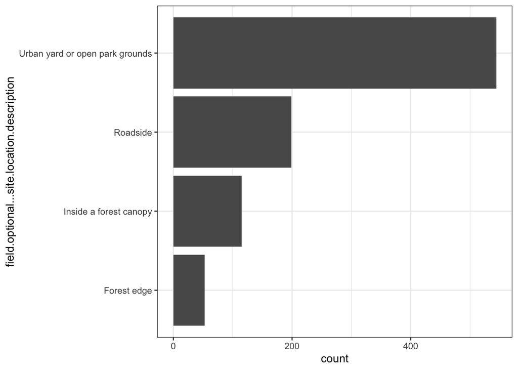

```r
ggplot(data.site.filter,aes(field.optional...site.location.description))+geom_histogram(stat="count")+coord_flip()+theme_bw()
```

##### All Trees

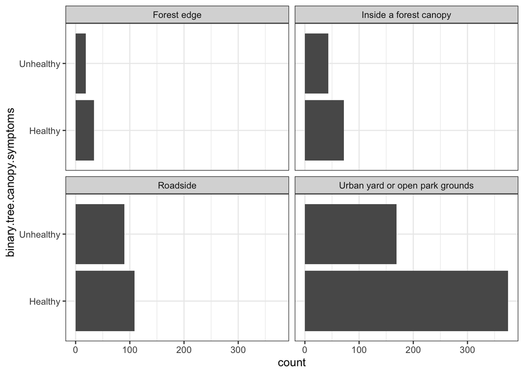

```r
ggplot(data.site.filter,aes(binary.tree.canopy.symptoms)) +facet_wrap(~field.optional...site.location.description) +geom_histogram(stat="count")+theme_bw()+coord_flip()
```

##### Trees with Dead Tops

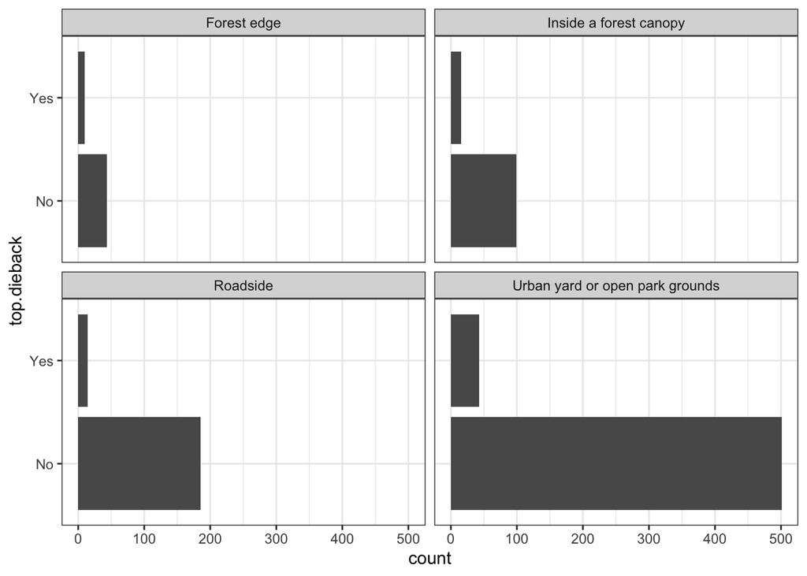

```r
ggplot(data.site.filter,aes(top.dieback)) +facet_wrap(~field.optional...site.location.description) +geom_histogram(stat="count")+theme_bw()+coord_flip()
```

##### Thinning Trees

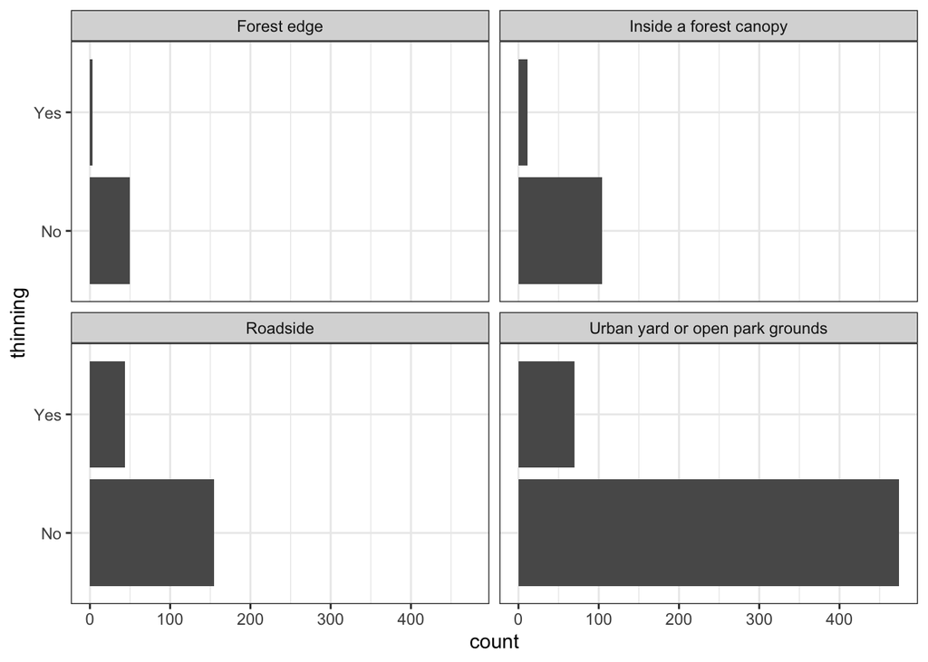

```r
ggplot(data.site.filter,aes(thinning)) +facet_wrap(~field.optional...site.location.description) +geom_histogram(stat="count")+theme_bw()+coord_flip()
```

#### Response 1.2 healthy / unhealthy

```r
data.site.filter$field.optional...site.location.description <- as.factor(data.site.filter$field.optional...site.location.description)

data.site.filter$field.optional...site.location.description <- relevel(data.site.filter$field.optional...site.location.description, ref = "Inside a forest canopy")
```

```r
binomial.af.site <- glmmTMB(binary.tree.canopy.symptoms ~ dist.from.mean.af + field.optional...site.location.description  + (1|Area),data=data.site.filter,family=binomial)
```

##### Overall Effect

```r
# Fit the reduced model (without site location description)
reduced_model.binomial.site <- glmmTMB(binary.tree.canopy.symptoms ~ dist.from.mean.af + (1 | Area),
                       data = data.site.filter,
                       family = binomial)

# Perform a likelihood ratio test
anova(reduced_model.binomial.site, binomial.af.site, test = "Chisq")
```

```
## Data: data.site.filter
## Models:
## reduced_model.binomial.site: binary.tree.canopy.symptoms ~ dist.from.mean.af + (1 | Area), zi=~0, disp=~1
## binomial.af.site: binary.tree.canopy.symptoms ~ dist.from.mean.af + field.optional...site.location.description + , zi=~0, disp=~1
## binomial.af.site:     (1 | Area), zi=~0, disp=~1
##                             Df    AIC    BIC  logLik deviance  Chisq Chi Df
## reduced_model.binomial.site  3 1149.8 1164.2 -571.88   1143.8
## binomial.af.site             6 1147.8 1176.7 -567.92   1135.8 7.9173      3
##                             Pr(>Chisq)
## reduced_model.binomial.site
## binomial.af.site               0.04775 *
## ---
## Signif. codes:  0 '***' 0.001 '**' 0.01 '*' 0.05 '.' 0.1 ' ' 1
```

The inclusion of the site variable improves the model fit, implying that the site location descriptions have a meaningful and statistically significant impact on the binary outcome binary.tree.canopy.symptoms.

##### Model Summary

```r
summary(binomial.af.site)
```

```
##  Family: binomial  ( logit )
## Formula:
## binary.tree.canopy.symptoms ~ dist.from.mean.af + field.optional...site.location.description +
##     (1 | Area)
## Data: data.site.filter
##
##      AIC      BIC   logLik deviance df.resid
##   1147.8   1176.7   -567.9   1135.8      905
##
## Random effects:
##
## Conditional model:
##  Groups Name        Variance Std.Dev.
##  Area   (Intercept) 0.1667   0.4083
## Number of obs: 911, groups:  Area, 3
##
## Conditional model:
##                                                                           Estimate
## (Intercept)                                                               -0.53046
## dist.from.mean.af                                                          0.14851
## field.optional...site.location.descriptionForest edge                      0.04091
## field.optional...site.location.descriptionRoadside                         0.13546
## field.optional...site.location.descriptionUrban yard or open park grounds -0.36074
##                                                                           Std. Error
## (Intercept)                                                                  0.31621
## dist.from.mean.af                                                            0.03594
## field.optional...site.location.descriptionForest edge                        0.36106
## field.optional...site.location.descriptionRoadside                           0.25177
## field.optional...site.location.descriptionUrban yard or open park grounds    0.23962
##                                                                           z value
## (Intercept)                                                                -1.678
## dist.from.mean.af                                                           4.132
## field.optional...site.location.descriptionForest edge                       0.113
## field.optional...site.location.descriptionRoadside                          0.538
## field.optional...site.location.descriptionUrban yard or open park grounds  -1.505
##                                                                           Pr(>|z|)
## (Intercept)                                                                 0.0934
## dist.from.mean.af                                                          3.6e-05
## field.optional...site.location.descriptionForest edge                       0.9098
## field.optional...site.location.descriptionRoadside                          0.5905
## field.optional...site.location.descriptionUrban yard or open park grounds   0.1322
##
## (Intercept)                                                               .
## dist.from.mean.af                                                         ***
## field.optional...site.location.descriptionForest edge
## field.optional...site.location.descriptionRoadside
## field.optional...site.location.descriptionUrban yard or open park grounds
## ---
## Signif. codes:  0 '***' 0.001 '**' 0.01 '*' 0.05 '.' 0.1 ' ' 1
```

#### Response 2.2 healthy / top-dieback

```r
data.top.site <- data.site.filter %>% filter(reclassified.tree.canopy.symptoms=="Healthy"|reclassified.tree.canopy.symptoms=="Dead Top") %>% droplevels()
```

```r
data.top.site$field.optional...site.location.description <- as.factor(data.top.site$field.optional...site.location.description)

data.top.site$field.optional...site.location.description <- relevel(data.top.site$field.optional...site.location.description, ref = "Inside a forest canopy")
```

```r
top.dieback.binomial.af.site <- glmmTMB(top.dieback ~ dist.from.mean.af + field.optional...site.location.description + (1|Area),data=data.top.site,family=binomial)
```

##### Overall Effect

```r
# Fit the reduced model (without site location description)
reduced_model.top.site <- glmmTMB(top.dieback ~ dist.from.mean.af + (1 | Area),
                       data = data.top.site,
                       family = binomial)

# Perform a likelihood ratio test
anova(reduced_model.top.site, top.dieback.binomial.af.site, test = "Chisq")
```

```
## Data: data.top.site
## Models:
## reduced_model.top.site: top.dieback ~ dist.from.mean.af + (1 | Area), zi=~0, disp=~1
## top.dieback.binomial.af.site: top.dieback ~ dist.from.mean.af + field.optional...site.location.description + , zi=~0, disp=~1
## top.dieback.binomial.af.site:     (1 | Area), zi=~0, disp=~1
##                              Df    AIC    BIC  logLik deviance  Chisq Chi Df
## reduced_model.top.site        3 476.09 489.63 -235.05   470.09
## top.dieback.binomial.af.site  6 474.38 501.45 -231.19   462.38 7.7184      3
##                              Pr(>Chisq)
## reduced_model.top.site
## top.dieback.binomial.af.site     0.0522 .
## ---
## Signif. codes:  0 '***' 0.001 '**' 0.01 '*' 0.05 '.' 0.1 ' ' 1
```

The inclusion of the site variable in the model provides a better fit, but the improvement is only marginally significant. This suggests that while site location descriptions may have an effect on top.dieback, the evidence is not strong enough to definitively conclude a significant overall effect at the 0.05 level. Further investigation or additional data might help clarify the importance of this predictor.

##### Model Summary

```r
summary(top.dieback.binomial.af.site)
```

```
##  Family: binomial  ( logit )
## Formula:
## top.dieback ~ dist.from.mean.af + field.optional...site.location.description +
##     (1 | Area)
## Data: data.top.site
##
##      AIC      BIC   logLik deviance df.resid
##    474.4    501.4   -231.2    462.4      667
##
## Random effects:
##
## Conditional model:
##  Groups Name        Variance Std.Dev.
##  Area   (Intercept) 0.7519   0.8671
## Number of obs: 673, groups:  Area, 3
##
## Conditional model:
##                                                                           Estimate
## (Intercept)                                                               -1.83775
## dist.from.mean.af                                                          0.21257
## field.optional...site.location.descriptionForest edge                      0.45747
## field.optional...site.location.descriptionRoadside                        -0.64557
## field.optional...site.location.descriptionUrban yard or open park grounds -0.62509
##                                                                           Std. Error
## (Intercept)                                                                  0.60028
## dist.from.mean.af                                                            0.07773
## field.optional...site.location.descriptionForest edge                        0.48784
## field.optional...site.location.descriptionRoadside                           0.41695
## field.optional...site.location.descriptionUrban yard or open park grounds    0.36636
##                                                                           z value
## (Intercept)                                                                -3.062
## dist.from.mean.af                                                           2.735
## field.optional...site.location.descriptionForest edge                       0.938
## field.optional...site.location.descriptionRoadside                         -1.548
## field.optional...site.location.descriptionUrban yard or open park grounds  -1.706
##                                                                           Pr(>|z|)
## (Intercept)                                                                0.00220
## dist.from.mean.af                                                          0.00624
## field.optional...site.location.descriptionForest edge                      0.34837
## field.optional...site.location.descriptionRoadside                         0.12155
## field.optional...site.location.descriptionUrban yard or open park grounds  0.08797
##
## (Intercept)                                                               **
## dist.from.mean.af                                                         **
## field.optional...site.location.descriptionForest edge
## field.optional...site.location.descriptionRoadside
## field.optional...site.location.descriptionUrban yard or open park grounds .
## ---
## Signif. codes:  0 '***' 0.001 '**' 0.01 '*' 0.05 '.' 0.1 ' ' 1
```

#### Response 3.2 healthy / thinning

```r
data.thin.site <- data.site.filter %>% filter(reclassified.tree.canopy.symptoms=="Healthy"|reclassified.tree.canopy.symptoms=="Thinning Canopy") %>% droplevels()
```

```r
data.thin.site$field.optional...site.location.description <- as.factor(data.thin.site$field.optional...site.location.description)

data.thin.site$field.optional...site.location.description <- relevel(data.thin.site$field.optional...site.location.description, ref = "Inside a forest canopy")
```

```r
thinning.binomial.af.site <- glmmTMB(thinning ~ dist.from.mean.af + field.optional...site.location.description + (1|Area),data=data.thin.site,family=binomial)
```

##### Overall Effect

```r
# Fit the reduced model (without site location description)
reduced_model.thin.site <- glmmTMB(thinning ~ dist.from.mean.af + (1 | Area),
                       data = data.thin.site,
                       family = binomial)

# Perform a likelihood ratio test
anova(reduced_model.thin.site, thinning.binomial.af.site, test = "Chisq")
```

```
## Data: data.thin.site
## Models:
## reduced_model.thin.site: thinning ~ dist.from.mean.af + (1 | Area), zi=~0, disp=~1
## thinning.binomial.af.site: thinning ~ dist.from.mean.af + field.optional...site.location.description + , zi=~0, disp=~1
## thinning.binomial.af.site:     (1 | Area), zi=~0, disp=~1
##                           Df    AIC    BIC  logLik deviance Chisq Chi Df
## reduced_model.thin.site    3 664.05 677.78 -329.02   658.05
## thinning.binomial.af.site  6 659.18 686.64 -323.59   647.18 10.87      3
##                           Pr(>Chisq)
## reduced_model.thin.site
## thinning.binomial.af.site    0.01245 *
## ---
## Signif. codes:  0 '***' 0.001 '**' 0.01 '*' 0.05 '.' 0.1 ' ' 1
```

The p-value of 0.01245 indicates that the inclusion of the field.optional…site.location.description variable significantly improves the model’s ability to predict thinning compared to the reduced model that only includes dist.from.mean.af.

adding the site variable to the model significantly enhances its ability to predict thinning in trees. The statistically significant improvement in model fit suggests that the site location descriptions contribute valuable information about the likelihood of thinning. Therefore, both the distance from mean temp and the specific site location should be considered important factors in understanding and predicting tree thinning.

##### Model Summary

```r
summary(thinning.binomial.af.site)
```

```
##  Family: binomial  ( logit )
## Formula:
## thinning ~ dist.from.mean.af + field.optional...site.location.description +
##     (1 | Area)
## Data: data.thin.site
##
##      AIC      BIC   logLik deviance df.resid
##    659.2    686.6   -323.6    647.2      712
##
## Random effects:
##
## Conditional model:
##  Groups Name        Variance Std.Dev.
##  Area   (Intercept) 0.1268   0.3561
## Number of obs: 718, groups:  Area, 3
##
## Conditional model:
##                                                                           Estimate
## (Intercept)                                                               -1.84097
## dist.from.mean.af                                                          0.12110
## field.optional...site.location.descriptionForest edge                     -0.47285
## field.optional...site.location.descriptionRoadside                         0.77358
## field.optional...site.location.descriptionUrban yard or open park grounds  0.08443
##                                                                           Std. Error
## (Intercept)                                                                  0.39740
## dist.from.mean.af                                                            0.05168
## field.optional...site.location.descriptionForest edge                        0.69207
## field.optional...site.location.descriptionRoadside                           0.38174
## field.optional...site.location.descriptionUrban yard or open park grounds    0.37521
##                                                                           z value
## (Intercept)                                                                -4.632
## dist.from.mean.af                                                           2.343
## field.optional...site.location.descriptionForest edge                      -0.683
## field.optional...site.location.descriptionRoadside                          2.026
## field.optional...site.location.descriptionUrban yard or open park grounds   0.225
##                                                                           Pr(>|z|)
## (Intercept)                                                               3.61e-06
## dist.from.mean.af                                                           0.0191
## field.optional...site.location.descriptionForest edge                       0.4945
## field.optional...site.location.descriptionRoadside                          0.0427
## field.optional...site.location.descriptionUrban yard or open park grounds   0.8220
##
## (Intercept)                                                               ***
## dist.from.mean.af                                                         *
## field.optional...site.location.descriptionForest edge
## field.optional...site.location.descriptionRoadside                        *
## field.optional...site.location.descriptionUrban yard or open park grounds
## ---
## Signif. codes:  0 '***' 0.001 '**' 0.01 '*' 0.05 '.' 0.1 ' ' 1
```

The Roadside location is significantly associated with a higher likelihood of thinning compared to the trees inside a forest canopy. In contrast, Forest edge and Urban yard or open park grounds do not show significant effects on thinning compared to trees inside a forest canopy.

The model suggests that the distance from mean temp is a key factor influencing tree thinning, with greater distances associated with higher thinning probabilities. Additionally, trees located near roadsides are more susceptible to thinning, indicating that site location plays a role, though not all site locations are equally influential. The variability across areas, as indicated by the random effect for Area, suggests that other unmeasured factors may also be at play in different regions.

# Overall Summary

## Core Models - 3 responses

| Area | Response | Explanatory | df.resid | Estimate | Std.Error | z-val | Pr(>z) | Signif. |
| --- | --- | --- | --- | --- | --- | --- | --- | --- |
| All Areas | healthy/unhealthy | Dist from Mean AF | 1101 | 0.13977 | 0.03219 | 4.343 | 1.41e-05 | *** |
| All Areas | no/dead-top | Dist from Mean AF | 812 | 0.2386 | 0.0688 | 3.468 | 0.000525 | *** |
| All Areas | no/thinning | Dist from Mean AF | 855 | 0.12305 | 0.04641 | 2.651 | 0.00802 | ** |

## Co Factors

### Size

#### Overall Effects

| Response | Model | DF | AIC | BIC | ChiSq | DF | Pr(>Chisq) | Signif. |
| --- | --- | --- | --- | --- | --- | --- | --- | --- |
| healthy/unhealthy | reduced_model.binomial.size | 3 | 1125.3 | 1139.6 |  |  |  |  |
| healthy/unhealthy | binomial.af.size | 5 | 1120.4 | 1144.3 | 8.8781 | 2 | 0.01181 | * |
| no/dead-top | reduced_model.top.size | 3 | 433.74 | 447.12 |  |  |  |  |
| no/dead-top | top.dieback.binomial.af.size | 5 | 427.83 | 450.13 | 9.9166 | 2 | 0.007025 | ** |
| no/thinning | reduced_model.thin.size | 3 | 667.69 | 681.34 |  |  |  |  |
| no/thinning | thinning.binomial.af.size | 5 | 663.68 | 686.43 | 8.0083 | 2 | 0.01824 | * |

#### Model Summaries

| Area | Response | Explanatory | df.resid | Estimate | Std.Error | z-val | Pr(>z) | Signif. |
| --- | --- | --- | --- | --- | --- | --- | --- | --- |
| All Areas | healthy/unhealthy | Dist from Mean AF | 876 | 0.13074 | 0.03459 | 3.779 | 0.000157 | *** |
| All Areas | healthy/unhealthy | Tree.Size.Medium | 876 | 0.28156 | 0.15542 | 1.812 | 0.070034 | . |
| All Areas | healthy/unhealthy | Tree.Size.Small | 876 | -0.63900 | 0.33293 | -1.919 | 0.054947 | . |
| All Areas | no/dead-top | Dist from Mean AF | 634 | 0.15033 | 0.07431 | 2.023 | 0.04307 | * |
| All Areas | no/dead-top | Tree.Size.Medium | 634 | 0.85568 | 0.27103 | 3.157 | 0.00159 | ** |
| All Areas | no/dead-top | Tree.Size.Small | 634 | 0.28621 | 0.48528 | 0.590 | 0.55533 |  |
| All Areas | no/thinning | Dist from Mean AF | 694 | 0.12852 | 0.04909 | 2.618 | 0.00884 | ** |
| All Areas | no/thinning | Tree.Size.Medium | 694 | 0.19655 | 0.21049 | 0.934 | 0.35042 |  |
| All Areas | no/thinning | Tree.Size.Small | 694 | -1.28676 | 0.61263 | -2.100 | 0.03569 | * |

### Location

#### Overall Effects

| Response | Model | DF | AIC | BIC | ChiSq | DF | Pr(>Chisq) | Signif. |
| --- | --- | --- | --- | --- | --- | --- | --- | --- |
| healthy/unhealthy | reduced_model.binomial.site | 3 | 1149.8 | 1164.2 |  |  |  |  |
| healthy/unhealthy | binomial.af.site | 6 | 1147.8 | 1176.7 | 7.9173 | 3 | 0.04775 | * |
| no/dead-top | reduced_model.top.site | 3 | 476.09 | 489.63 |  |  |  |  |
| no/dead-top | top.dieback.binomial.af.site | 6 | 474.38 | 501.45 | 7.7184 | 3 | 0.0522 | . |
| no/thinning | reduced_model.thin.site | 3 | 664.05 | 677.78 |  |  |  |  |
| no/thinning | thinning.binomial.af.site | 6 | 659.18 | 686.64 | 10.87 | 3 | 0.01245 | * |

#### Model Summaries

| Area | Response | Explanatory | df.resid | Estimate | Std.Error | z-val | Pr(>z) | Signif. |
| --- | --- | --- | --- | --- | --- | --- | --- | --- |
| All Areas | healthy/unhealthy | Dist from Mean AF | 905 | 0.14851 | 0.03594 | 4.132 | 3.6e-05 | *** |
| All Areas | healthy/unhealthy | Forest edge | 905 | 0.04091 | 0.36106 | 0.113 | 0.9098 |  |
| All Areas | healthy/unhealthy | Roadside | 905 | 0.13546 | 0.25177 | 0.538 | 0.5905 |  |
| All Areas | healthy/unhealthy | Urban yard or open park grounds | 905 | -0.36074 | 0.23962 | -1.505 | 0.1322 |  |
| All Areas | no/dead-top | Dist from Mean AF | 667 | 0.21257 | 0.07773 | 2.735 | 0.00624 | ** |
| All Areas | no/dead-top | Forest edge | 667 | 0.45747 | 0.48784 | 0.938 | 0.34837 |  |
| All Areas | no/dead-top | Roadside | 667 | -0.64557 | 0.41695 | -1.548 | 0.12155 |  |
| All Areas | no/dead-top | Urban yard or open park grounds | 667 | -0.62509 | 0.36636 | -1.706 | 0.08797 |  |
| All Areas | no/thinning | Dist from Mean AF | 712 | 0.12110 | 0.05168 | 2.343 | 0.019122 | * |
| All Areas | no/thinning | Forest edge | 712 | -0.47285 | 0.69207 | -0.683 | 0.4945 |  |
| All Areas | no/thinning | Roadside | 712 | 0.77358 | 0.38174 | 2.026 | 0.0427 | * |
| All Areas | no/thinning | Urban yard or open park grounds | 712 | 0.08443 | 0.37521 | 0.225 | 0.8220 |  |